# ML2: Exam Preparation

Denis Baskan

10 March 2019

# Exercise: Tree Models

In the following code, a Regression tree and Classification tree will be applied. Some parts are from the book James et. al. Lab 8.3.2.

## Load Packages

If packages are not installed, then they will be installed.

```r
#load needed packages; if not installed, then do so
required.packages =  c('MASS')#c('forecast', 'tseries', 'ggplot2', 'gsubfn','Metrics')#,'prophet
load.packages <- function(packages){

  for (pckg in packages){
    if (!(pckg %in% installed.packages()[,"Package"])){
      install.packages(pckg)
    }

    library(pckg, character.only = TRUE)
  }
}
load.packages(required.packages)
```

# Show Boston data set and some scatterplots

The data set contains data on housing values and other information about Boston suburbs.

```r
#The data set contains data on housing values and other information about Boston suburbs.
?Boston
head(Boston)
```

|  | crim | zn | indus | chas | nox | rm | age | dis | rad | tax | ptratio | black | lstat | medv |
| --- | --- | --- | --- | --- | --- | --- | --- | --- | --- | --- | --- | --- | --- | --- |
| 1 | 0.00632 | 18 | 2.31 | 0 | 0.538 | 6.575 | 65.2 | 4.0900 | 1 | 296 | 15.3 | 396.90 | 4.98 | 24.0 |
| 2 | 0.02731 | 0 | 7.07 | 0 | 0.469 | 6.421 | 78.9 | 4.9671 | 2 | 242 | 17.8 | 396.90 | 9.14 | 21.6 |
| 3 | 0.02729 | 0 | 7.07 | 0 | 0.469 | 7.185 | 61.1 | 4.9671 | 2 | 242 | 17.8 | 392.83 | 4.03 | 34.7 |
| 4 | 0.03237 | 0 | 2.18 | 0 | 0.458 | 6.998 | 45.8 | 6.0622 | 3 | 222 | 18.7 | 394.63 | 2.94 | 33.4 |
| 5 | 0.06905 | 0 | 2.18 | 0 | 0.458 | 7.147 | 54.2 | 6.0622 | 3 | 222 | 18.7 | 396.90 | 5.33 | 36.2 |
| 6 | 0.02985 | 0 | 2.18 | 0 | 0.458 | 6.430 | 58.7 | 6.0622 | 3 | 222 | 18.7 | 394.12 | 5.21 | 28.7 |

```r
cat("Number of rows: ", nrow(Boston))
```

```
Number of rows:  506
```

```r
cat("Number of columns: ", ncol(Boston))
```

```
Number of columns:  14
```

```r
cat("Column names: ", colnames(Boston))
```

```
Column names:  crim zn indus chas nox rm age dis rad tax ptratio black lstat medv
```

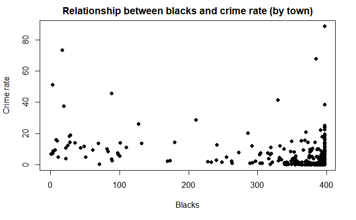

```r
plot(black,crim,main="Relationship between blacks and crime rate (by town)", xlab="Blacks", ylab="Crime rate", pch=19)
```

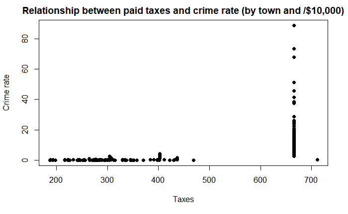

```r
plot(tax,crim,main="Relationship between paid taxes and crime rate (by town and /$10,000)", xlab="Taxes", ylab="Crime rate", pch=19)
```

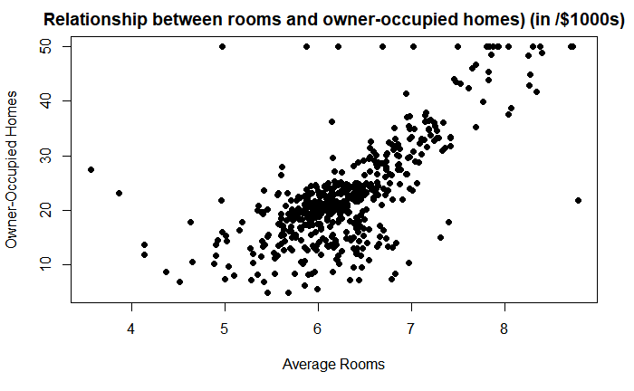

```r
plot(rm,medv,main="Relationship between rooms and owner-occupied homes) (in /$1000s)", xlab="Average Rooms", ylab="Owner-Occupied Homes", pch=19)
```

## Any suburbs with particularly high crime rate? Tax rates? Pupil-teacher ratios?

```r
#x-axis has no meaning

plot(Boston[order(Boston$crim),]$crim,main="Crime Rate", xlab="Suburb", ylab="Crime rate (by town)", pch=19,type='l')
plot(Boston[order(Boston$tax),]$tax,main="Taxes", xlab="Suburb", ylab="Taxes", pch=19,type='l')
plot(Boston[order(Boston$ptratio),]$ptratio,main="Pupil-Teacher ratio", xlab="Suburb", ylab="Pupil-Teacher ratio", pch=19,type='l')
```

[output not shown]

## Some Statistics

```r
cat("Number of suburbs bound the Charles river: ",sum(Boston$chas==1))
```

```
Number of suburbs bound the Charles river:  35
```

```r
cat("Median value of pupil-teacher ratio : ",median(Boston$ptratio))
```

```
Median value of pupil-teacher ratio :  19.05
```

```r
cat("Lowest median value of owner-occupied homes : ",min(Boston$medv))
```

```
Lowest median value of owner-occupied homes :  5
```

```r
cat("Number of suburbs with more than 7 rooms per dwelling: ",sum(Boston$rm > 7))
```

```
Number of suburbs with more than 7 rooms per dwelling:  64
```

```r
cat("Number of suburbs with more than 8 rooms per dwelling: ",sum(Boston$rm > 8))
```

```
Number of suburbs with more than 8 rooms per dwelling:  13
```

```r
#compare some data
Boston[Boston$medv==min(Boston$medv),]
```

|  | crim | zn | indus | chas | nox | rm | age | dis | rad | tax | ptratio | black | lstat | medv |
| --- | --- | --- | --- | --- | --- | --- | --- | --- | --- | --- | --- | --- | --- | --- |
| 399 | 38.3518 | 0 | 18.1 | 0 | 0.693 | 5.453 | 100 | 1.4896 | 24 | 666 | 20.2 | 396.90 | 30.59 | 5 |
| 406 | 67.9208 | 0 | 18.1 | 0 | 0.693 | 5.683 | 100 | 1.4254 | 24 | 666 | 20.2 | 384.97 | 22.98 | 5 |

```r
print("These 2 suburbs have high values for the predictors crime, black, tax, pt-ratio.")
```

```
[1] "These 2 suburbs have high values for the predictors crime, black, tax, pt-ratio."
```

The data with more than 8 rooms have a low crime rate and high values for age, tax, black for example. The 2 suburbs with the lowest medv values have high values for the predictors crime, black, tax, pt-ratio. One can conclude that populations with a lower status and cheap houses are at increased risk of being a crime victim.

# Fit a Regression tree using column medv as outcome variable

```r
#Note: outcome variable should be continuous. Exercise follows Lab 8.3.2 in James et al.
set.seed(1) #set a fix random generator to reproduce the same results next time
train = sample(1:nrow(Boston), nrow(Boston)/2)   #split data randomly
tree.boston = rpart(medv ~.,Boston,subset=train) # create a tree
print(tree.boston) #only 3 variables were used
```

```
n= 253

node), split, n, deviance, yval
      * denotes terminal node

 1) root 253 20894.66000 22.67312
   2) lstat>=9.715 150  3464.71500 17.55133
     4) lstat>=21.49 30   311.88970 11.10333 *
     5) lstat< 21.49 120  1593.69900 19.16333
      10) lstat>=14.48 58   743.28220 17.15690 *
      11) lstat< 14.48 62   398.48920 21.04032 *
   3) lstat< 9.715 103  7764.58400 30.13204
     6) rm< 7.437 89  3310.16000 27.57640
      12) rm< 6.7815 61  1994.62200 25.52131
        24) dis>=2.85155 54   544.00830 24.32778
          48) rm< 6.36 22    47.17864 21.82273 *
          49) rm>=6.36 32   263.86000 26.05000 *
        25) dis< 2.85155 7   780.27430 34.72857 *
      13) rm>=6.7815 28   496.64960 32.05357 *
     7) rm>=7.437 14   177.84360 46.37857 *
```

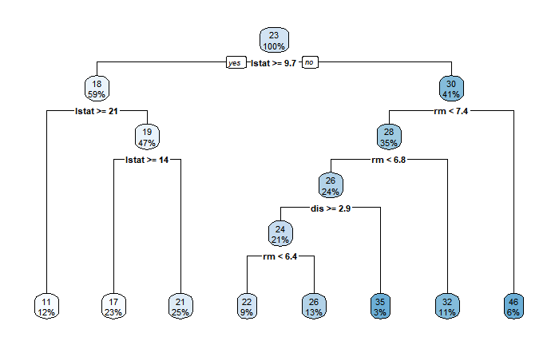

```r
rpart.plot(tree.boston)
```

The tree indicates that a higher socioeconomic status leads in buying more expensive houses. A median house price of $46,000 can be observed when lstat is lower than 9.7% and number of rooms are higher than 7.4 on average.

## Can pruning the tree improve our model?

Rule: Choose the smalles number of nodes (largest cp value) which lies within 1 std. dev. of the smallest deviance, i.e. lies below the dotted line.

```r
printcp(tree.boston)
```

```
Regression tree:
rpart(formula = medv ~ ., data = Boston, subset = train)

Variables actually used in tree construction:
[1] dis   lstat rm

Root node error: 20895/253 = 82.588

n= 253

        CP nsplit rel error  xerror     xstd
1 0.462576      0   1.00000 1.01273 0.117728
2 0.204673      1   0.53742 0.56339 0.059699
3 0.074618      2   0.33275 0.34949 0.039945
4 0.039191      3   0.25813 0.29608 0.039976
5 0.032082      4   0.21894 0.31072 0.048076
6 0.021629      5   0.18686 0.29508 0.048053
7 0.011150      6   0.16523 0.26146 0.042604
8 0.010000      7   0.15408 0.25032 0.037014
```

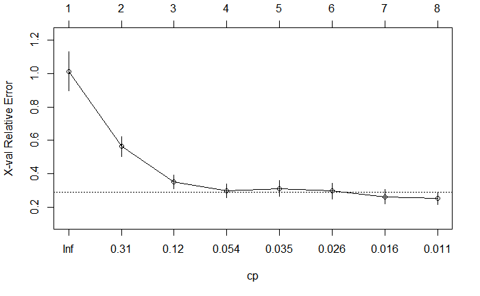

```r
plotcp(tree.boston)
```

cp=0.016 lies below the dotted line and could improve our model

## Prune the tree and compare models

```r
prune.boston = prune(tree.boston,cp=0.016)
prune.boston
```

```
n= 253

node), split, n, deviance, yval
      * denotes terminal node

 1) root 253 20894.6600 22.67312
   2) lstat>=9.715 150  3464.7150 17.55133
     4) lstat>=21.49 30   311.8897 11.10333 *
     5) lstat< 21.49 120  1593.6990 19.16333
      10) lstat>=14.48 58   743.2822 17.15690 *
      11) lstat< 14.48 62   398.4892 21.04032 *
   3) lstat< 9.715 103  7764.5840 30.13204
     6) rm< 7.437 89  3310.1600 27.57640
      12) rm< 6.7815 61  1994.6220 25.52131
        24) dis>=2.85155 54   544.0083 24.32778 *
        25) dis< 2.85155 7   780.2743 34.72857 *
      13) rm>=6.7815 28   496.6496 32.05357 *
     7) rm>=7.437 14   177.8436 46.37857 *
```

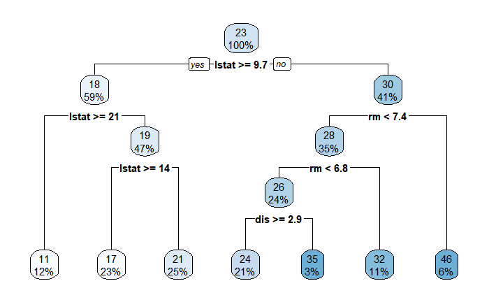

```r
rpart.plot(prune.boston)
```

```r
#compare models by calculating MSE (Mean Squarred Error)
pred.train<-predict(tree.boston,newdata=Boston[train,])
mean((Boston$medv[train]-pred.train)^2)
```

```
[1] 12.72517
```

```r
pred.train.prune<-predict(prune.boston,newdata=Boston[train,])
mean((Boston$medv[train]-pred.train.prune)^2)
```

```
[1] 13.646
```

## Calculate the MSE for the test set

```r
pred.test<-predict(tree.boston,newdata=Boston[-train,])
mean((Boston$medv[-train]-pred.test)^2)
```

```
[1] 25.35825
```

```r
pred.test<-predict(prune.boston,newdata=Boston[-train,])
mean((Boston$medv[-train]-pred.test)^2)
```

```
[1] 25.82207
```

Pruned tree performes slightly worse applied on train and test set, but we gained a simpler model. Taking the square root of the test set MSE gives $5,000 rounded. That’s the range where test prediction lay in.

## Plot observed median values medv agains predictions

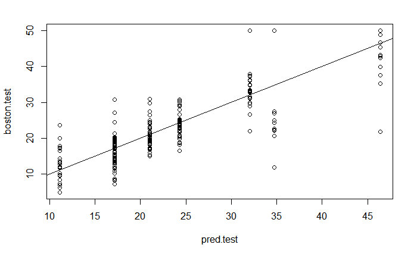

```r
boston.test=Boston[-train,"medv"]
plot(pred.test,boston.test)
abline(c(0,1))
```